# Unit Project 2

Caleb Kang

2026-03-11

# Lecture 6

```r
penguins <- penguins %>%
  drop_na(flipper_length_mm, body_mass_g, bill_length_mm, bill_depth_mm, sex)
```

#Q1 Answer: Adding theme_minimal() changes the background to be white colored.

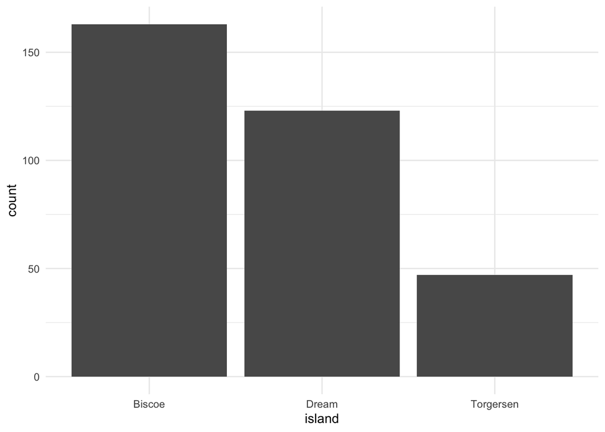

```r
ggplot(data = penguins) +
geom_bar(aes(x = island)) +
theme_minimal()
```

#Q2 Answer: The general shape of the distribution is normal. Bin number changes how many bars appear, allowing for a more detailed and complicated graph. Adelie has the largest peaks in counts, while Chinstrap has the smallest counts. Adelie and Chinstrap have a similar mean, but Gentoo has a considerably larger mean.

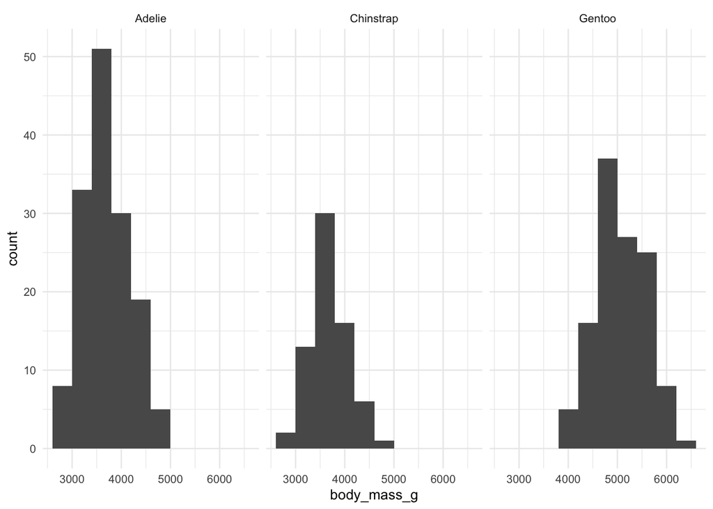

```r
ggplot(penguins, aes(x = body_mass_g)) +
  geom_histogram(bins = 10) + facet_wrap(~ species) +
  theme_minimal(base_size = 10)
```

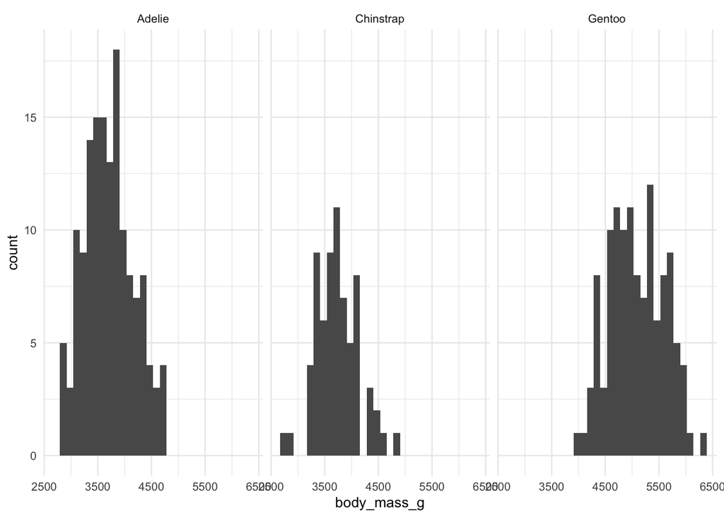

```r
ggplot(penguins, aes(x = body_mass_g)) +
  geom_histogram(bins = 30) +
  facet_wrap(~ species) +
  theme_minimal(base_size = 10)
```

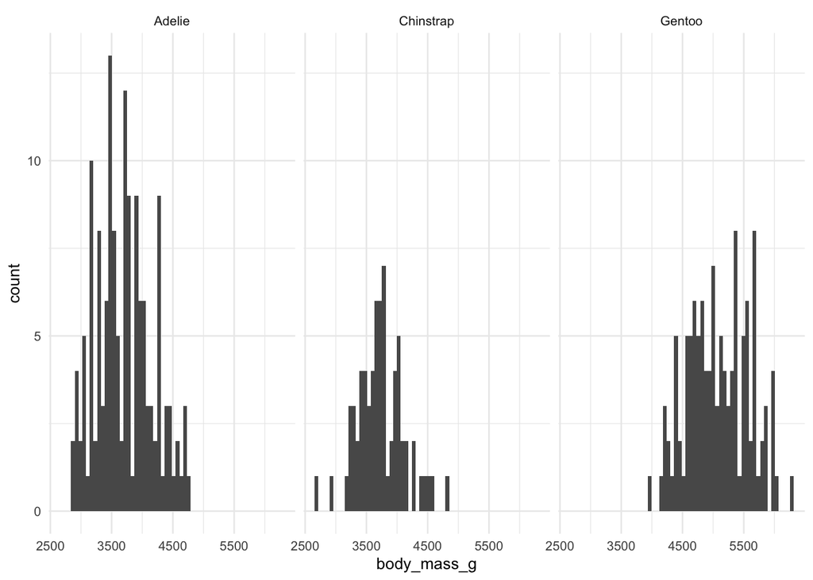

```r
ggplot(penguins, aes(x = body_mass_g)) +
  geom_histogram(bins = 60) +
  facet_wrap(~ species) +
  theme_minimal(base_size = 10)
```

#Q3 Answer: Gentoo has the longest flippers. Males have a greater body mass. The fill=species command doesn’t really help readability in this plot, likely would in a scatter plot though. However, the fill=species command does allow further separation of the data by species.

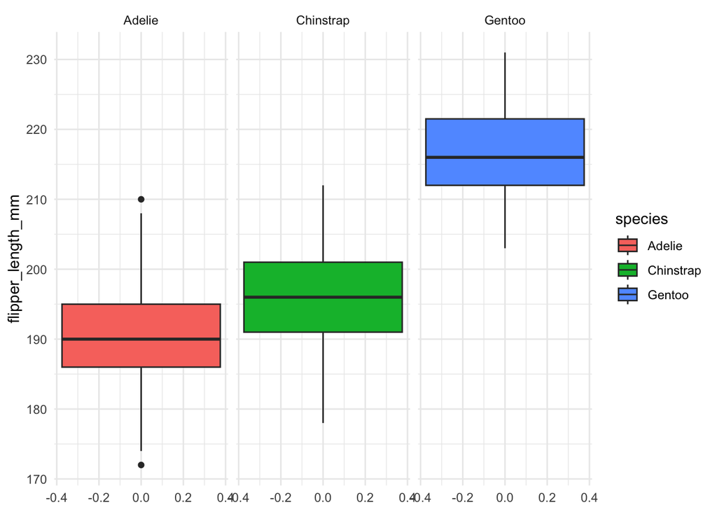

```r
ggplot(penguins, aes(y = flipper_length_mm, fill = species)) +
  geom_boxplot() +
  facet_wrap(~ species) +
  theme_minimal()
```

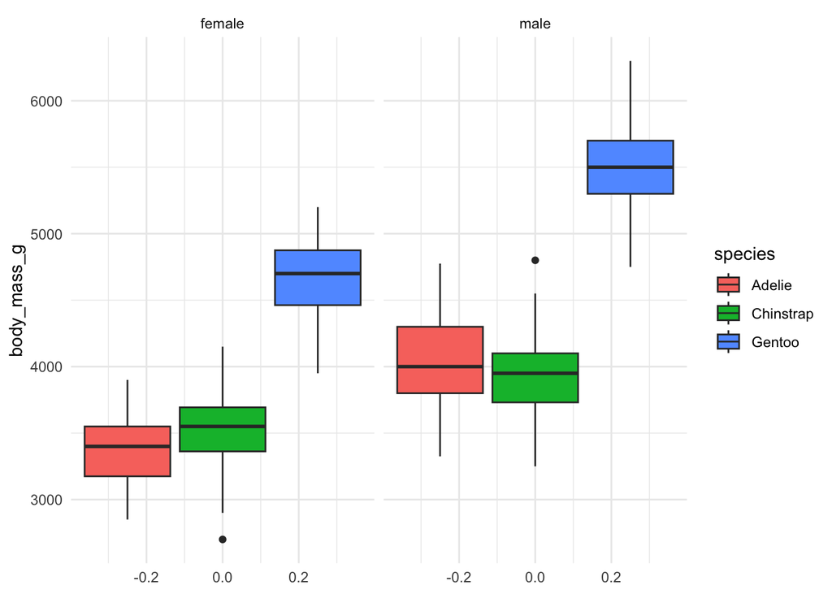

```r
ggplot(penguins, aes(y = body_mass_g, fill = species)) +
  geom_boxplot() +
  facet_wrap(~ sex) +
  theme_minimal()
```

#Q4 Answer: The relationship is unclear but if I had to guess I would say positive. Coloring the plot by species significantly helps the readability, as now I can see there is a positive trend in all 3 of the species. The line fits the data and shows the positive trend, but there is a lot of variability in the plots to consider.

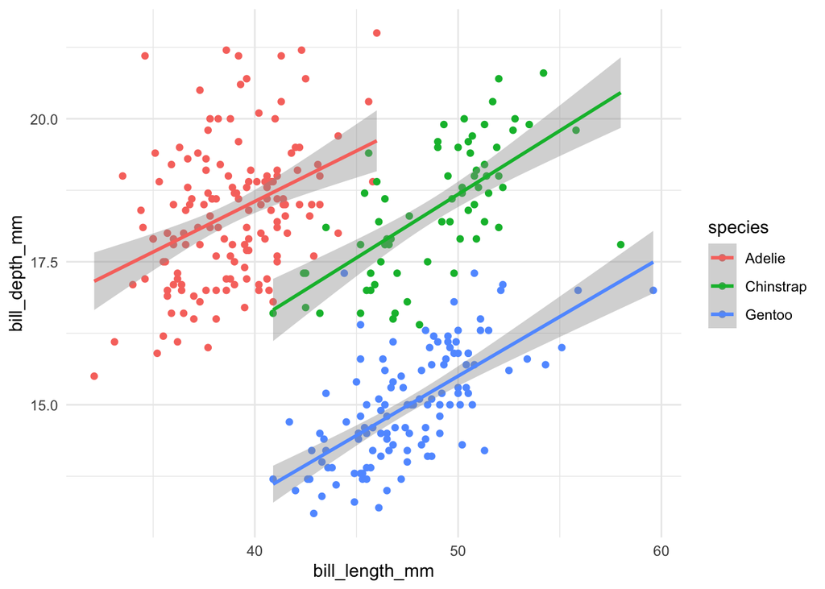

```r
ggplot(penguins, aes(x = bill_length_mm, y = bill_depth_mm, color = species)) +
  geom_point() +
  geom_smooth(method = "lm") +
  theme_minimal()
```

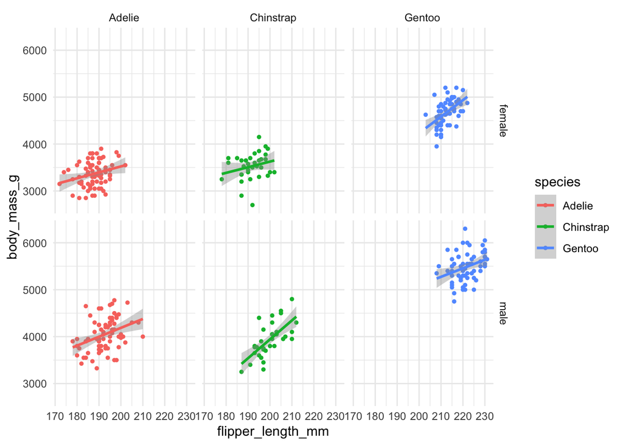

```r
ggplot(penguins, aes(x = flipper_length_mm, y = body_mass_g, color = species)) +
  geom_point(size = 1) +
  facet_grid(sex ~ species) +
  geom_smooth(method = "lm") +
  theme_minimal()
```

#Q6

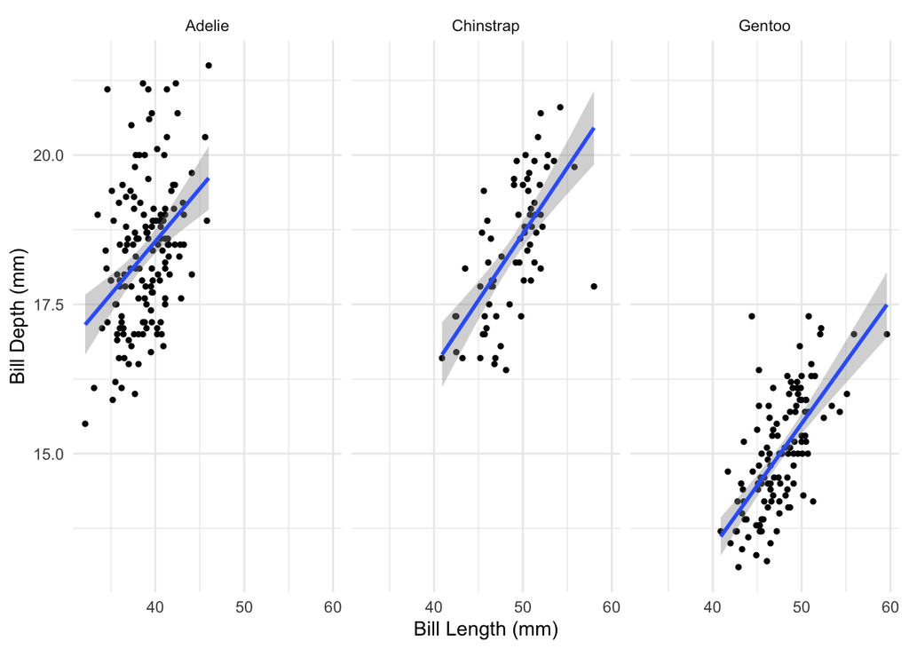

```r
ggplot(penguins, aes(x = bill_length_mm, y = bill_depth_mm)) +
  geom_point(size = 1) +
  facet_wrap(~ species) +
  geom_smooth(method = "lm") +
  labs(x = "Bill Length (mm)", y = "Bill Depth (mm)") +
  theme_minimal()
```

#Q7 Answer: The most fun part of this exercise was learning about and using all of the different tools and customizations you can use to make a graph more detailed and organized. The most difficult part was also learning about all the different factors you need to know, but it was still fun.

# Lecture 07

#Q1

```r
str_detect(penguins_messy$species_messy, "adelie")
```

```
##   [1]  TRUE  TRUE  TRUE  TRUE  TRUE  TRUE  TRUE  TRUE  TRUE  TRUE  TRUE  TRUE
##  [13]  TRUE  TRUE  TRUE  TRUE  TRUE  TRUE  TRUE  TRUE  TRUE  TRUE  TRUE  TRUE
##  [25]  TRUE  TRUE  TRUE  TRUE  TRUE  TRUE  TRUE  TRUE  TRUE  TRUE  TRUE  TRUE
##  [37]  TRUE  TRUE  TRUE  TRUE  TRUE  TRUE  TRUE  TRUE  TRUE  TRUE  TRUE  TRUE
##  [49]  TRUE  TRUE  TRUE  TRUE  TRUE  TRUE  TRUE  TRUE  TRUE  TRUE  TRUE  TRUE
##  [61]  TRUE  TRUE  TRUE  TRUE  TRUE  TRUE  TRUE  TRUE  TRUE  TRUE  TRUE  TRUE
##  [73]  TRUE  TRUE  TRUE  TRUE  TRUE  TRUE  TRUE  TRUE  TRUE  TRUE  TRUE  TRUE
##  [85]  TRUE  TRUE  TRUE  TRUE  TRUE  TRUE  TRUE  TRUE  TRUE  TRUE  TRUE  TRUE
##  [97]  TRUE  TRUE  TRUE  TRUE  TRUE  TRUE  TRUE  TRUE  TRUE  TRUE  TRUE  TRUE
## [109]  TRUE  TRUE  TRUE  TRUE  TRUE  TRUE  TRUE  TRUE  TRUE  TRUE  TRUE  TRUE
## [121]  TRUE  TRUE  TRUE  TRUE  TRUE  TRUE  TRUE  TRUE  TRUE  TRUE  TRUE  TRUE
## [133]  TRUE  TRUE  TRUE  TRUE  TRUE  TRUE  TRUE  TRUE  TRUE  TRUE  TRUE  TRUE
## [145]  TRUE  TRUE  TRUE  TRUE  TRUE  TRUE  TRUE  TRUE FALSE FALSE FALSE FALSE
## [157] FALSE FALSE FALSE FALSE FALSE FALSE FALSE FALSE FALSE FALSE FALSE FALSE
## [169] FALSE FALSE FALSE FALSE FALSE FALSE FALSE FALSE FALSE FALSE FALSE FALSE
## [181] FALSE FALSE FALSE FALSE FALSE FALSE FALSE FALSE FALSE FALSE FALSE FALSE
## [193] FALSE FALSE FALSE FALSE FALSE FALSE FALSE FALSE FALSE FALSE FALSE FALSE
## [205] FALSE FALSE FALSE FALSE FALSE FALSE FALSE FALSE FALSE FALSE FALSE FALSE
## [217] FALSE FALSE FALSE FALSE FALSE FALSE FALSE FALSE FALSE FALSE FALSE FALSE
## [229] FALSE FALSE FALSE FALSE FALSE FALSE FALSE FALSE FALSE FALSE FALSE FALSE
## [241] FALSE FALSE FALSE FALSE FALSE FALSE FALSE FALSE FALSE FALSE FALSE FALSE
## [253] FALSE FALSE FALSE FALSE FALSE FALSE FALSE FALSE FALSE FALSE FALSE FALSE
## [265] FALSE FALSE FALSE FALSE FALSE FALSE FALSE FALSE FALSE FALSE FALSE FALSE
## [277] FALSE FALSE FALSE FALSE FALSE FALSE FALSE FALSE FALSE FALSE FALSE FALSE
## [289] FALSE FALSE FALSE FALSE FALSE FALSE FALSE FALSE FALSE FALSE FALSE FALSE
## [301] FALSE FALSE FALSE FALSE FALSE FALSE FALSE FALSE FALSE FALSE FALSE FALSE
## [313] FALSE FALSE FALSE FALSE FALSE FALSE FALSE FALSE FALSE FALSE FALSE FALSE
## [325] FALSE FALSE FALSE FALSE FALSE FALSE FALSE FALSE FALSE FALSE FALSE FALSE
## [337] FALSE FALSE FALSE FALSE FALSE FALSE FALSE FALSE
```

```r
str_replace_all(penguins_messy$sex_messy, "\\?", "")
```

```
##   [1] "M" "f" "f" NA  "f" "M" "f" "M" NA  NA  NA  NA  "f" "M" "M" "f" "f" "M"
##  [19] "f" "M" "f" "M" "f" "M" "M" "f" "M" "f" "f" "M" "f" "M" "f" "M" "f" "M"
##  [37] "M" "f" "f" "M" "f" "M" "f" "M" "f" "M" "M" NA  "f" "M" "f" "M" "f" "M"
##  [55] "f" "M" "f" "M" "f" "M" "f" "M" "f" "M" "f" "M" "f" "M" "f" "M" "f" "M"
##  [73] "f" "M" "f" "M" "f" "M" "f" "M" "f" "M" "f" "M" "f" "M" "M" "f" "M" "f"
##  [91] "f" "M" "f" "M" "f" "M" "f" "M" "f" "M" "f" "M" "f" "M" "f" "M" "f" "M"
## [109] "f" "M" "f" "M" "f" "M" "f" "M" "f" "M" "f" "M" "f" "M" "f" "M" "f" "M"
## [127] "f" "M" "f" "M" "f" "M" "f" "M" "f" "M" "f" "M" "f" "M" "f" "M" "f" "M"
## [145] "f" "M" "M" "f" "f" "M" "f" "M" "f" "M" "f" "M" "M" "f" "f" "M" "f" "M"
## [163] "f" "M" "f" "M" "f" "M" "f" "M" "f" "M" "M" "f" "f" "M" "f" "M" NA  "M"
## [181] "f" "M" "M" "f" "f" "M" "f" "M" "f" "M" "f" "M" "f" "M" "f" "M" "M" "f"
## [199] "f" "M" "f" "M" "f" "M" "f" "M" "f" "M" "f" "M" "f" "M" "f" "M" "f" "M"
## [217] "f" "M" NA  "M" "f" "M" "f" "M" "M" "f" "f" "M" "f" "M" "f" "M" "f" "M"
## [235] "f" "M" "f" "M" "f" "M" "f" "M" "f" "M" "f" "M" "f" "M" "M" "f" "f" "M"
## [253] "f" "M" "f" "M" NA  "M" "f" "M" "f" "M" "f" "M" "f" "M" "f" "M" NA  "M"
## [271] "f" NA  "f" "M" "f" "M" "f" "M" "M" "f" "M" "f" "f" "M" "f" "M" "f" "M"
## [289] "f" "M" "f" "M" "M" "f" "f" "M" "f" "M" "f" "M" "f" "M" "f" "M" "f" "M"
## [307] "f" "M" "f" "M" "M" "f" "f" "M" "f" "M" "M" "f" "M" "f" "f" "M" "f" "M"
## [325] "M" "f" "f" "M" "f" "M" "f" "M" "f" "M" "M" "f" "M" "f" "f" "M" "f" "M"
## [343] "M" "f"
```

```r
str_squish(penguins_messy$island_messy)
```

```
##   [1] "Torgersen" "Torgersen" "Torgersen" "Torgersen" "Torgersen" "Torgersen"
##   [7] "Torgersen" "Torgersen" "Torgersen" "Torgersen" "Torgersen" "Torgersen"
##  [13] "Torgersen" "Torgersen" "Torgersen" "Torgersen" "Torgersen" "Torgersen"
##  [19] "Torgersen" "Torgersen" "BIS-COE"   "BIS-COE"   "BIS-COE"   "BIS-COE"
##  [25] "BIS-COE"   "BIS-COE"   "BIS-COE"   "BIS-COE"   "BIS-COE"   "BIS-COE"
##  [31] "Dream"     "Dream"     "Dream"     "Dream"     "Dream"     "Dream"
##  [37] "Dream"     "Dream"     "Dream"     "Dream"     "Dream"     "Dream"
##  [43] "Dream"     "Dream"     "Dream"     "Dream"     "Dream"     "Dream"
##  [49] "Dream"     "Dream"     "BIS-COE"   "BIS-COE"   "BIS-COE"   "BIS-COE"
##  [55] "BIS-COE"   "BIS-COE"   "BIS-COE"   "BIS-COE"   "BIS-COE"   "BIS-COE"
##  [61] "BIS-COE"   "BIS-COE"   "BIS-COE"   "BIS-COE"   "BIS-COE"   "BIS-COE"
##  [67] "BIS-COE"   "BIS-COE"   "Torgersen" "Torgersen" "Torgersen" "Torgersen"
##  [73] "Torgersen" "Torgersen" "Torgersen" "Torgersen" "Torgersen" "Torgersen"
##  [79] "Torgersen" "Torgersen" "Torgersen" "Torgersen" "Torgersen" "Torgersen"
##  [85] "Dream"     "Dream"     "Dream"     "Dream"     "Dream"     "Dream"
```

[output cut: 43 more lines]

#Q2

Answer: 316

```r
penguins_messy<-penguins_messy %>%
  mutate(valid_id = str_detect(sample_id, "PAL-[0-9]{3}"))

penguins_messy %>%
  pull(valid_id) %>%
  sum()
```

```
## [1] 316
```

#Q3

```r
penguins_messy<-penguins_messy %>%
  filter(valid_id)
```

#Q4

Answer:

```r
penguins_messy<-penguins_messy %>%
  mutate(file_date = str_extract(file_name, "^[0-9]{4}-[0-9]{2}-[0-9]{2}"), file_id   = str_extract(file_name, "PAL-[0-9]{3}"))

penguins_messy %>%
  pull(file_date) %>%
  head(10)
```

```
##  [1] "2024-01-14" "2024-01-17" "2024-01-08" "2024-01-26" "2024-01-06"
##  [6] "2024-01-08" "2024-01-08" "2024-01-19" "2024-01-14" "2024-01-24"
```

```r
penguins_messy %>%
  pull(file_id) %>%
  head(10)
```

```
##  [1] "PAL-535" "PAL-442" "PAL-668" "PAL-920" "PAL-223" "PAL-899" "PAL-268"
##  [8] "PAL-139" "PAL-847" "PAL-238"
```

#Q5

```r
penguins_messy<-penguins_messy %>%
  mutate(island = str_squish(island_messy))

unique(penguins_messy$island)
```

```
## [1] "Torgersen" "BIS-COE"   "Dream"
```

#Q6

```r
penguins_messy<-penguins_messy %>%
  mutate(sex = sex_messy %>%
  str_replace_all("\\?", "") %>%
  str_to_upper())

unique(penguins_messy$sex)
```

```
## [1] "M" "F" NA
```

#Q7

```r
penguins_messy<-penguins_messy %>%
  mutate(bill_mm = notes %>%
  str_replace_all("(.*bill=)|mm", "") %>%
  as.numeric())
```

#Q8

Answer: It was fun to fix penguins_messy because it was similar to a puzzle. Figuring everything out was confusing since there’s a good amount of new commands to learn. I believe I have a general idea of how regular expressions work and when to use them.

# Lecture 8

#Q1

```r
penguins_clean<-penguins %>%
  drop_na(bill_length_mm, sex)

nrow(penguins_clean)
```

```
## [1] 333
```

```r
nrow(penguins)
```

```
## [1] 333
```

#Q2

Answer: Duplicates can alter the means, medians, standard deviations, lines of best fit, and so on from what they should actually be.

```r
penguins_dup<-penguins_clean %>%
  bind_rows(slice_sample(penguins_clean, n=30, replace=TRUE))

nrow(penguins_dup)
```

```
## [1] 363
```

```r
penguins_dupless<-penguins_dup %>%
  distinct()

nrow(penguins_dupless)
```

```
## [1] 333
```

#Q3

Answer: 8 coulumns

```r
q3data<-penguins_clean %>%
  select(species, island, sex, where(is.numeric))

ncol(q3data)
```

```
## [1] 8
```

#Q4

```r
penguins_clean %>% select(starts_with("bill"))
```

```
## # A tibble: 333 × 2
##    bill_length_mm bill_depth_mm
##             <dbl>         <dbl>
##  1           39.1          18.7
##  2           39.5          17.4
##  3           40.3          18
##  4           36.7          19.3
##  5           39.3          20.6
##  6           38.9          17.8
##  7           39.2          19.6
##  8           41.1          17.6
##  9           38.6          21.2
## 10           34.6          21.1
## # ℹ 323 more rows
```

```r
penguins_clean %>% select(ends_with("_mm"))
```

```
## # A tibble: 333 × 3
##    bill_length_mm bill_depth_mm flipper_length_mm
##             <dbl>         <dbl>             <int>
##  1           39.1          18.7               181
##  2           39.5          17.4               186
##  3           40.3          18                 195
##  4           36.7          19.3               193
##  5           39.3          20.6               190
##  6           38.9          17.8               181
##  7           39.2          19.6               195
##  8           41.1          17.6               182
##  9           38.6          21.2               191
## 10           34.6          21.1               198
## # ℹ 323 more rows
```

```r
penguins_clean %>% select(matches("bill|flipper"))
```

```
## # A tibble: 333 × 3
##    bill_length_mm bill_depth_mm flipper_length_mm
##             <dbl>         <dbl>             <int>
##  1           39.1          18.7               181
##  2           39.5          17.4               186
##  3           40.3          18                 195
##  4           36.7          19.3               193
##  5           39.3          20.6               190
##  6           38.9          17.8               181
##  7           39.2          19.6               195
##  8           41.1          17.6               182
##  9           38.6          21.2               191
## 10           34.6          21.1               198
## # ℹ 323 more rows
```

#Q5

Answer: By using this command instead of typing them all out by hand, we save time and decrease the likelihood of typos in our code.

```r
penguins_clean %>%
  group_by(species) %>%
  summarize(across(where(is.numeric), mean, na.rm = TRUE))
```

```
## # A tibble: 3 × 6
##   species   bill_length_mm bill_depth_mm flipper_length_mm body_mass_g  year
##   <fct>              <dbl>         <dbl>             <dbl>       <dbl> <dbl>
## 1 Adelie              38.8          18.3              190.       3706. 2008.
## 2 Chinstrap           48.8          18.4              196.       3733. 2008.
## 3 Gentoo              47.6          15.0              217.       5092. 2008.
```

#Q6

```r
penguins_clean<-penguins_clean %>%
  mutate(bill_length = case_when(
    bill_length_mm < 40 ~ "short",
    bill_length_mm < 50 ~ "medium",
    bill_length_mm >= 50 ~ "long",
    TRUE ~ NA_character_))
```

#Q7

Answer: There is 9 columns in penguins_clean and 12 columns in penguins_instrumented.

```r
instrument_meta <- tibble(
  instrument_id = c("caliper_A", "caliper_B", "caliper_C"),
  calibration_mm = c(0.2, 0.5, 1.0),
  manufacturer = c("Mitutoyo", "Fowler", "Generic")
)

penguins_instrumented<-penguins_clean %>%
  drop_na(bill_length_mm) %>%
  mutate(instrument_id = case_when(
    year == 2007 ~ "caliper_A",
    year == 2008 ~ "caliper_B",
    year == 2009 ~ "caliper_C",
    TRUE ~ NA_character_)) %>%
  left_join(instrument_meta, by = "instrument_id")

ncol(penguins_clean)
```

```
## [1] 9
```

```r
ncol(penguins_instrumented)
```

```
## [1] 12
```

#Q8

Answer: It was fun trying to solve all the questions. It got confusing when I had to start combining certain commands into one big one. I don’t know if I’ll be doing much data analysis in my future, but if I do this will definetly help me.